# Frozen-family check: FB vs MR correspondence under non-regenerating cuts

```r
library(forestsearch)
library(survival)
library(data.table)
library(doFuture)
library(kableExtra)

timings <- list()
print(getwd())
```

```
[1] "/home/larryleon/Documents/GitHub/forestsearch/quarto/applications/gbsg"
```

```r
# Guo & He comparator: guohe_algorithm3() / fs_to_guohe() are package API
# (exported by forestsearch). gh_dir is kept only for the LOO cache path below.
gh_dir <- Sys.getenv("GH_DIR", unset = "../../../quarto/GuoHe")

# ---------------------------------------------------------------------------
# Output location for this document's results:  <base>/<dirout>/
#   results_dir = NULL -> base is <qmd dir>/_payloads
#   dirout      = NULL -> the .qmd stem
# Setting results_dir redirects the base only; each run still gets its own
# subdirectory named by dirout.
#
# Examples:
#   results_dir <- NULL;  dirout <- NULL
#     -> <qmd dir>/_payloads/<stem>/<stem>_payload.rds
#   results_dir <- NULL;  dirout <- "gbsg_survival_frozen_family"
#     -> <qmd dir>/_payloads/gbsg_survival_frozen_family/gbsg_survival_frozen_family_payload.rds
#   results_dir <- "~/GitHub/fs-post-selection-manuscript_jasa/_payloads"; dirout <- NULL
#     -> ~/GitHub/fs-post-selection-manuscript_jasa/_payloads/<stem>/<stem>_payload.rds
# ---------------------------------------------------------------------------
results_dir <- NULL
# TASK_gbsg_frozen_complement_2026-09-06: committed payloads are read-only, so
# this render writes beside the committed frozen-family payload rather than
# over it (the tracked HTML is refreshed per the directory's convention).
dirout      <- "analysis_gbsg_survival_frozen_family_complement"
```

```r
n_cores <- max(1L, floor(0.80 * parallel::detectCores(logical = FALSE)))
NB         <- 1000L     # full-bootstrap resamples, matching the headline run
mr_draws <- 5000L     # MR multiplier draws
GH_B       <- 1000L     # Guo & He pair-bootstrap resamples
GH_r       <- 0.03      # Guo & He tuning parameter
GH_PARALLEL <- .Platform$OS.type == "unix"   # forked GH bootstrap where available
run_loo    <- TRUE      # leave-one-out (N-fold) honest out-of-sample subgroup estimate
timings$loo <- NA_real_
# LOO fold-loop workers: 80% of physical cores (the same rule as n_cores above),
# so this adapts to whichever machine renders. There is no nested parallelism to
# guard against: forestsearch_Kfold() pins each fold's inner forestsearch() refit
# to plan = "sequential", workers = 1, so these are the ONLY workers in play.
# Replace with a fixed integer to pin it.
loo_workers <- n_cores
run_cv_kfold <- TRUE     # repeated 10-fold cross-validation (stability diagnostics)
Ksims       <- 50L      # repeated 10-fold partitions (>= 50 for production)
timings$kfold <- NA_real_
cat("Using", n_cores, "workers (80% of",
    parallel::detectCores(logical = FALSE), "physical cores);",
    "LOO fold-loop workers:", loo_workers, "\n")
```

```
Using 102 workers (80% of 128 physical cores); LOO fold-loop workers: 102
```

```r
df.analysis <- gbsg
df.analysis <- within(df.analysis, {
  id <- seq_len(nrow(df.analysis))
  time_months <- rfstime / 30.4375
  grade3 <- ifelse(grade == "3", 1, 0)
})

# The forced cuts are computed ONCE on the observed data and hard-coded as
# fixed-threshold expressions, so the bootstrap replay cannot move them.
med <- sapply(c("age", "size", "nodes", "pgr", "er"),
              function(v) stats::median(df.analysis[[v]]))
frozen_cuts <- c(
  sprintf("age <= %g",   med[["age"]]),     # observed median
  sprintf("size <= %g",  med[["size"]]),
  sprintf("nodes <= %g", med[["nodes"]]),
  sprintf("pgr <= %g",   med[["pgr"]]),
  sprintf("er <= %g",    med[["er"]]),
  "er <= 0",                                 # receptor-negative (clinical)
  "pgr <= 0"
)
cat("Frozen cuts (fixed thresholds, replayed verbatim under bootstrap):\n")
```

```
Frozen cuts (fixed thresholds, replayed verbatim under bootstrap):
```

```r
cat(paste0("  ", frozen_cuts), sep = "\n")
```

```
  age <= 53
  size <= 25
  nodes <= 3
  pgr <= 32.5
  er <= 36
  er <= 0
  pgr <= 0
```

```r
# CATEGORICAL factors only in confounders.name: the continuous factors are
# DROPPED so forestsearch never auto-cuts (and never quantile-recomputes) them.
confounders.name <- c("meno", "grade3")

outcome.name <- "time_months"
event.name   <- "status"
id.name      <- "id"
treat.name   <- "hormon"
```

## 0.1 Parameter provenance

Each `forestsearch()` fit carries `args_call_all`: the argument list the call actually resolved to, kept in sync by the package’s `.sync_args_call_all()` and used by `forestsearch()` for reconstruction. The table below reconciles it against `formals(forestsearch)` at render time, so the values reported are the ones the fit used rather than restated comments that can drift.

```r
.fs_fmt_val <- function(v) {
  if (is.null(v)) return("NULL")
  if (is.data.frame(v)) return(sprintf("<data.frame %d x %d>", nrow(v), ncol(v)))
  if (is.function(v)) return("<function>")
  if (is.list(v)) {
    if (length(v) == 0L) return("list()")
    nms <- names(v); if (is.null(nms)) nms <- rep("", length(v))
    inner <- vapply(seq_along(v), function(i) {
      val <- tryCatch(paste(deparse(v[[i]], width.cutoff = 200L), collapse = " "),
                      error = function(e) "<?>")
      if (nzchar(nms[i])) paste0(nms[i], " = ", val) else val
    }, character(1))
    return(paste0("list(", paste(inner, collapse = ", "), ")"))
  }
  if (length(v) > 6L) return(sprintf("<%s[%d]>", class(v)[1], length(v)))
  paste(deparse(v, width.cutoff = 200L), collapse = " ")
}

.fs_fmt_default <- function(x) {
  if (identical(x, quote(expr = ))) return("<required; no default>")
  paste(deparse(x, width.cutoff = 200L), collapse = " ")
}

# match.arg-style values resolve to their first element.  Applied to BOTH sides
# of the comparison below: a value captured unresolved (grf_selection,
# grf_select_statistic) still sits at its default and must not read as differing.
.fs_collapse_matcharg <- function(x) {
  ifelse(!is.na(x) & grepl('^c[(]"', x),
         sub('^c[(]"([^"]*)".*$', '"\\1"', x), x)
}

#' Reconcile a fit's resolved arguments against forestsearch()'s formals
fs_param_provenance <- function(fit, fn = forestsearch) {
  stopifnot(!is.null(fit), !is.null(fit$args_call_all))
  args <- fit$args_call_all
  fm   <- formals(fn)
  nm   <- setdiff(names(fm), "...")

  defaults <- vapply(fm[nm], .fs_fmt_default, character(1), USE.NAMES = FALSE)
  used <- vapply(nm, function(p) {
    if (!p %in% names(args)) return(NA_character_)
    .fs_fmt_val(args[[p]])
  }, character(1), USE.NAMES = FALSE)

  eff      <- .fs_collapse_matcharg(defaults)
  eff_used <- .fs_collapse_matcharg(used)

  out <- data.frame(
    parameter  = nm,
    default    = defaults,
    value_used = ifelse(is.na(used), "(not captured)", used),
    status     = ifelse(is.na(used), "not captured",
                 ifelse(eff_used == eff, "at default", "differs from default")),
    stringsAsFactors = FALSE
  )

  # forestsearch_main.R:1304 overrides these five under sg_focus = "maxeff" and
  # does NOT re-sync args_call_all afterwards (the package notes this itself at
  # ~2763), so what was captured is the value typed into the call, not the value
  # the engine ran with.
  if (identical(args$sg_focus, "maxeff")) {
    .ov <- c("pconsistency.threshold", "stop_threshold", "use_twostage",
             "max_subgroups_search", "minp")
    i <- out$parameter %in% .ov
    out$status[i] <- "captured BEFORE maxeff override -- not what the engine used"
  }

  out
}

#' Render a provenance table for one fit
fs_param_table <- function(fit, title) {
  pv <- fs_param_provenance(fit)
  n_diff <- sum(pv$status == "differs from default")
  sub <- sprintf(
    "%d of %d formals differ from their package default (forestsearch %s, read at render time).",
    n_diff, nrow(pv),
    tryCatch(as.character(utils::packageVersion("forestsearch")),
             error = function(e) "version unknown"))
  # Only meaningful when the maxeff override actually fired; under any other
  # sg_focus nothing is overridden and the caveat would be false.
  if (any(grepl("^captured BEFORE", pv$status))) {
    sub <- paste(sub,
      "args_call_all is not re-synced after the sg_focus = \"maxeff\" override block",
      "(forestsearch_main.R:1304; the package notes this itself at ~2763), so the",
      "rows flagged as such report the value typed into the call rather than the",
      "value the engine used -- the render's own maxeff warning lists those.")
  }
  knitr::kable(pv, caption = paste0(title, " -- ", sub))
}
```

## 0.2 Frozen-family fit

Every continuous factor is represented only by fixed median cuts (plus the receptor-negative cuts); the continuous factors themselves are excluded from the confounder set, and `conf.cont_jcuts` is not used. The candidate family is therefore fully determined by the fixed cuts and cannot regenerate under bootstrap resampling.

```
[forestsearch] Subgroup Identification Configuration
  Outcome type:   survival (Cox PH)
  Effect measure: HR (hazard ratio)
  Scale:          log (ratio)

  Screening:      HR >= 1.25  (log: 0.2231)
  Consistency:    HR >= 1.00  (log: 0.0000)
  Consistency rate threshold: 0%

  Interpretation:
    Candidates: subgroup hazard ratio >= 1.25
    Splits:     each split HR >= 1.00
```

```
  Search Alignment Diagnostic
```

```
  Outcome:    time_months (survival)
```

```
  Treatment:  hormon
```

```
  Measure:    Hazard Ratio (HR)
```

```
  ForestSearch searches for:
    Subgroups where hormon increases the event hazard
    (HR >= threshold in the candidate subgroup)
```

```
  Thresholds:
    Screening: HR >= 1.250 in the candidate subgroup
    Consistency: HR >= 1.000 in each bootstrap split
```

```
  Variable screening:
```

```
    LASSO: LASSO screening: DISABLED
```

```
    GRF:   DISABLED
```

```
  No alignment concerns detected.
```

```
Forced confounders: age <= 53, size <= 25, nodes <= 3, pgr <= 32.5, er <= 36, er <= 0, pgr <= 0
Candidate factors: 9
[1] "meno"        "grade3"      "age <= 53"   "size <= 25"  "nodes <= 3"
[6] "pgr <= 32.5" "er <= 36"    "er <= 0"     "pgr <= 0"
Number of possible configurations (<= maxk): maxk = 2 , # combinations = 171
Per-arm events criteria: control >= 10, treatment >= 10
Sample size criteria: n >= 60
Subgroup search completed in 0.01 minutes

--- Filtering Summary ---
  Combinations evaluated: 171
  Passed variance check: 160
  Passed prevalence (>= 0 ): 160
  Passed redundancy check: 158
  Passed events counts (d0>= 10, d1>= 10): 128
  Passed sample size (n>= 60 ): 118
  Cox model fit successfully: 118
  Passed effect threshold (effect >= 1.2500): 118
-------------------------

Found 118 subgroup candidate(s)
# of candidate subgroups (meeting all criteria) = 118
# of unique initial candidates: 116
# Restricting to top stop_Kgroups = Inf
# of candidates to evaluate: 116

==============================================================================================================
CANDIDATE EVALUATION PREVIEW (pre-consistency) (sg_focus = "maxeff", selection_rule = "neighborhood")
==============================================================================================================
Rank  HR      N      E     K    OF  Subgroup
--------------------------------------------------------------------------------------------------------------
   1   2.222     75    41    2  *   {pgr <= 32.5} & {er <= 0}
   2   1.951     82    45    1  *   {er <= 0}
   3   1.381     77    46    2  -   {er <= 36} & {pgr <= 0}
   4   1.274     88    53    1  *   {pgr <= 0}
   5   1.150    115    58    2  *   {grade3} & {er <= 36}
   6   1.133    138    73    2  *   !{meno} & {pgr <= 32.5}
   7   1.129    170   101    2  *   !{size <= 25} & {pgr <= 32.5}
   8   1.087     92    47    2  -   {grade3} & !{size <= 25}
   9   1.053    127    68    2  -   {grade3} & {pgr <= 32.5}
  10   1.045    163    87    2  -   !{size <= 25} & {er <= 36}
... 106 more candidates not shown (max_print = 10).
--------------------------------------------------------------------------------------------------------------
To evaluate: 116   On frontier: 17
Legend: OF = on Pareto frontier.
==============================================================================================================

116 subgroups passed consistency threshold
```

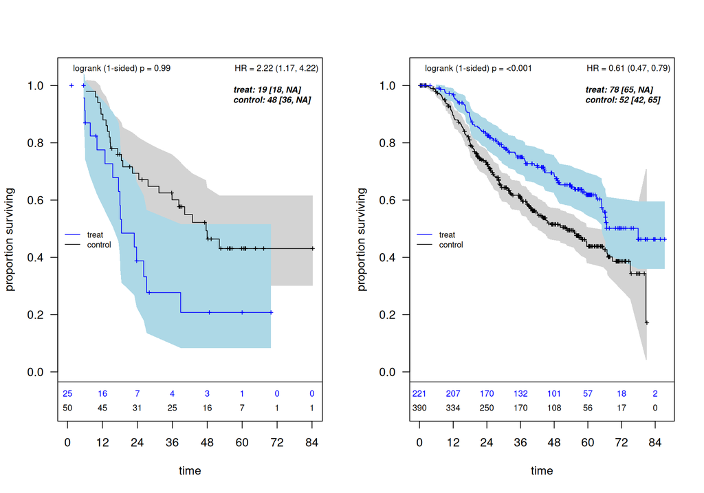

```
*** Subgroup found: {pgr <= 32.5} {er <= 0}
% consistency criteria met= 0.99
SG focus = maxeff

==============================================================================================================
CANDIDATE EVALUATION SUMMARY  (sg_focus = "maxeff", selection_rule = "neighborhood")
==============================================================================================================
Rank  HR      N      E     K    OF  S  Subgroup
--------------------------------------------------------------------------------------------------------------
   1   2.222     75    41    2  *   *  {pgr <= 32.5} & {er <= 0}
   2   1.951     82    45    1  *   -  {er <= 0}
   3   1.381     77    46    2  -   -  {er <= 36} & {pgr <= 0}
   4   1.274     88    53    1  *   -  {pgr <= 0}
   5   1.150    115    58    2  *   -  {grade3} & {er <= 36}
   6   1.133    138    73    2  *   -  !{meno} & {pgr <= 32.5}
   7   1.129    170   101    2  *   -  !{size <= 25} & {pgr <= 32.5}
   8   1.087     92    47    2  -   -  {grade3} & !{size <= 25}
   9   1.053    127    68    2  -   -  {grade3} & {pgr <= 32.5}
  10   1.045    163    87    2  -   -  !{size <= 25} & {er <= 36}
... 106 more candidates not shown (max_print = 10).
--------------------------------------------------------------------------------------------------------------
Evaluated: 116   Passed: 116   On frontier: 17   Selected: m=1
Selected subgroup Pcons (consistency probability): 0.990
Legend: OF = on Pareto frontier; S = selected.
==============================================================================================================

Seconds and minutes forestsearch overall = 0.813 0.0136
Consistency algorithm used: fixed
Subgroup identified: {pgr <= 32.5} & {er <= 0}
```

```
Multiplier resampling (MR): constructing de-biased estimates from 5000 draws.
  This is post-selection inference on the completed search; it cannot change the identified subgroup.
```

```
MR harm confirmation: HR = 1.753 (point rule vs 1.00) -> consistent with harm
```

```r
t0 <- proc.time()

fs <- forestsearch(
  df.analysis,
  outcome.name       = outcome.name,
  event.name         = event.name,
  treat.name         = treat.name,
  id.name            = id.name,
  confounders.name   = confounders.name,   # categorical only
  is.RCT             = TRUE,
  seedit             = 8316951,
  est.scale          = "hr",
  use_lasso          = FALSE,
  use_grf            = FALSE,
  use_dina           = FALSE,
  conf_force         = frozen_cuts,        # all cuts fixed
  # conf.cont_jcuts intentionally OMITTED -- no quantile cuts
  collapse_cuts      = TRUE,
  subgroup_method    = "consistency",
  sg_focus           = "maxeff",
  n.min              = 60, d0.min = 10, d1.min = 10, maxk = 2,
  mr_inference        = TRUE,
  # TASK_gbsg_frozen_intervals_2026-09-05 (+ its Gate 0 resolution): under
  # ci_method = "field" the de-biased (IJ) block is identical to the previous
  # render, so every existing MR number reproduces; the field block and the
  # re-selection frequencies are additive.  I1 as revised by Larry: the
  # uniform (kappa) calibration runs with the mass-carrying cap lifted to the
  # full family (field_M_cap = 1000L >= K), and its kappa-widened two-sided
  # interval is reported in @sec-intervals as the conservative uniformly-valid
  # option per REPORT_mr_field_uniform_2026-09-06.md.
  # TASK_gbsg_frozen_complement_2026-09-06: the complement's field block
  # (field_complement = TRUE; include_complement is forestsearch()'s default
  # and is stated for the record) and, with it, field$joint.  ij_residual is
  # left at its default ("two_term") so every reported number is computed as
  # before; the reported complement construction is MR (field).
  mr_inference_args   = list(draws = mr_draws, ci_method = "field",
                             return_reselection = TRUE,
                             field_uniform = TRUE, field_M_cap = 1000L,
                             include_complement = TRUE, field_complement = TRUE),
  consistency_method = "resample",
  # stop_threshold: INERT here.  forestsearch_main.R:1304 sets it to NULL under
  # sg_focus = "maxeff", together with pconsistency.threshold -> 0,
  # use_twostage -> FALSE, max_subgroups_search -> Inf and minp -> 0, and warns
  # listing the overrides.  The engine never sees the value below.
  fs.splits          = 1000, stop_threshold = 0.95,
  use_twostage       = TRUE, max.minutes = 3,
  show_candidate_summary = TRUE, details = TRUE, quiet = FALSE,
  plot.sg            = TRUE,
  parallel_args = list(plan = "multisession", workers = n_cores,
                       show_message = TRUE)
)
```

```r
plan("sequential")
timings$fit <- (proc.time() - t0)[["elapsed"]]
stopifnot(!is.null(fs$sg.harm))
cat("\nSelected subgroup:", paste(fs$sg.harm, collapse = " & "),
    "  |  fit", round(timings$fit / 60, 1), "min\n")
```

```
Selected subgroup: {pgr <= 32.5} & {er <= 0}   |  fit 1.3 min
```

Resolved parameters for the frozen-family fit – 16 of 85 formals differ from their package default (forestsearch 0.3.5, read at render time). args_call_all is not re-synced after the sg_focus = “maxeff” override block (forestsearch_main.R:1304; the package notes this itself at ~2763), so the rows flagged as such report the value typed into the call rather than the value the engine used – the render’s own maxeff warning lists those.

| parameter | default | value_used | status |
| --- | --- | --- | --- |
| df.analysis | <required; no default> | <data.frame 686 x 14> | differs from default |
| outcome.name | “tte” | “time_months” | differs from default |
| event.name | “event” | “status” | differs from default |
| treat.name | “treat” | “hormon” | differs from default |
| id.name | “id” | “id” | at default |
| potentialOutcome.name | NULL | NULL | at default |
| flag_harm.name | NULL | NULL | at default |
| confounders.name | NULL | c(“meno”, “grade3”) | differs from default |
| parallel_args | list(plan = “multisession”, workers = .default_parallel_workers(), show_message = TRUE) | list(plan = “multisession”, workers = 102, show_message = TRUE) | differs from default |
| df.predict | NULL | NULL | at default |
| df.test | NULL | NULL | at default |
| is.RCT | TRUE | TRUE | at default |
| seedit | 8316951 | 8316951 | at default |
| est.scale | “hr” | “hr” | at default |
| use_lasso | FALSE | FALSE | at default |
| use_grf | FALSE | FALSE | at default |
| grf_res | NULL | NULL | at default |
| grf_cuts | NULL | NULL | at default |
| use_dina | FALSE | FALSE | at default |
| dina_res | NULL | NULL | at default |
| dina_cuts | NULL | NULL | at default |
| dina_args | list() | list(select_statistic = “effect”) | differs from default |
| dina_select_statistic | c(“effect”, “dina”) | “effect” | at default |
| subgroup_method | c(“consistency”, “dina”, “grf”) | “consistency” | at default |
| max_n_confounders | 1000 | 1000 | at default |
| grf_depth | 2 | 2 | at default |
| grf_selection | c(“frontier”, “tree”) | c(“frontier”, “tree”) | at default |
| grf_select_statistic | c(“effect”, “dr”) | c(“effect”, “dr”) | at default |
| dmin.grf | 0 | 0 | at default |
| frac.tau | 0.8 | 0.8 | at default |

[output cut: 55 more lines]

### 0.2.1 Gate 0 – confirm the family is actually frozen

The whole check is void if any candidate cut is quantile-derived (hence regenerating). Verify that the realized candidate family contains only the fixed cuts: every cut label must correspond to one of the forced expressions or a categorical factor level, and no continuous factor may appear as an auto-derived cut. This is a hard gate – if it fails, stop; the comparison below is not interpretable.

```r
fam <- as.data.frame(fs$grp.consistency$out_sg$result)
mcols <- grep("^M\\.[0-9]+$", names(fam), value = TRUE)
labels <- unique(unlist(lapply(mcols, function(cn) fam[[cn]])))
labels <- labels[nzchar(labels)]

# Normalize a family cut label ("{er <= 0}", "!{age <= 53}") to its inner form.
norm_lab <- function(x) {
  x <- sub("^!", "", trimws(x))
  trimws(sub("^\\{", "", sub("\\}$", "", x)))
}
inner <- sort(unique(norm_lab(labels)))

# Allowed inner forms: the forced cuts, plus categorical factor cuts on
# meno / grade3 (which forestsearch may encode as "meno <= 0" / bare levels).
allowed_fixed <- frozen_cuts
cat("Distinct candidate cut forms in the realized family:\n")
```

```
Distinct candidate cut forms in the realized family:
```

```r
cat(paste0("  ", inner), sep = "\n")
```

```
  age <= 53
  er <= 0
  er <= 36
  grade3
  meno
  nodes <= 3
  pgr <= 0
  pgr <= 32.5
  size <= 25
```

```r
# Flag any cut on a continuous factor that is NOT one of the fixed thresholds.
cont_vars <- c("age", "size", "nodes", "pgr", "er")
offending <- inner[
  vapply(inner, function(s) {
    v <- sub("\\s*(<=|>=|<|>|==).*$", "", s)
    v <- trimws(v)
    (v %in% cont_vars) && !(s %in% trimws(sub("\\s+", " ", allowed_fixed)))
  }, logical(1))
]

if (length(offending)) {
  stop("GATE 0 FAILED -- continuous-factor cuts not in the fixed set are ",
       "present (family is NOT frozen): ",
       paste(offending, collapse = "; "))
}
cat("\nGATE 0 PASS -- every continuous-factor cut is a fixed threshold; ",
    "the family cannot regenerate under bootstrap.\n", sep = "")
```

```
GATE 0 PASS -- every continuous-factor cut is a fixed threshold; the family cannot regenerate under bootstrap.
```

## 0.3 Full bootstrap (FB)

```r
t0 <- proc.time()
fs_bc <- forestsearch_bootstrap_dofuture(
  fs.est   = fs, nb_boots = NB, show_three = FALSE, details = FALSE,
  parallel_args = list(plan = "multisession", workers = n_cores,
                       show_message = TRUE)
)
```

```
Bootstrap parallel config: Using user-provided settings
```

```
System max cores available: 128
```

```
Bootstrap will use: 102 workers with 'multisession' plan
```

```
Parallel plan: multisession with 102 workers.
```

```
Bootstrap iteration 1/1000
```

```
Bootstrap iteration 10/1000
```

```
Bootstrap iteration 50/1000
```

```
Bootstrap iteration 100/1000
```

```
Bootstrap iteration 250/1000
```

```
Bootstrap iteration 500/1000
```

```
Bootstrap iteration 750/1000
```

```
Bootstrap iteration 1000/1000
```

```r
plan("sequential")
timings$fb <- (proc.time() - t0)[["elapsed"]]
cat("FB completed in", round(timings$fb / 60, 1), "min\n")
```

```
FB completed in 2.5 min
```

## 0.4 Multiplier resampling (MR)

```r
g <- fs$mr_inference
stopifnot(!is.null(g))
timings$mr <- g$timing_seconds
cat("MR gate:", round(timings$mr, 2), "s over",
    format(mr_draws, big.mark = ","), "draws\n")
```

```
MR gate: 0.59 s over 5,000 draws
```

## 0.5 Guo & He (GH)

The adapter exports the frozen candidate family as membership columns and runs Guo & He Algorithm 3 on the same selected subgroup, asserting membership integrity against `fit$grp.consistency$sg.harm.id` before the estimator runs. The frozen family is coarser than the headline maxeff family (about 116 candidates versus ~1340), which remains well within the range where the argmax de-biasing is meaningful.

```r
t0 <- proc.time()
gh <- fs_to_guohe(
  fit       = fs,
  time      = "time_months", event = "status", treatment = "hormon",
  B         = GH_B, r = GH_r, level = 0.05, seed = 8316951,
  parallel  = GH_PARALLEL, verify = TRUE
)
timings$gh <- (proc.time() - t0)[["elapsed"]]
cat("GH family size:", length(gh$export$candidates),
    " | selected:", gh$selected,
    " | GH", round(timings$gh / 60, 1), "min\n")
```

```
GH family size: 116  | selected: sg_0001  | GH 0.5 min
```

```r
cat(sprintf("GH  naive HR %.3f  debiased HR %.3f  lower bound %.3f\n",
            gh$naive_hr, gh$debiased_hr, gh$bound_hr))
```

```
GH  naive HR 2.222  debiased HR 1.360  lower bound 0.962
```

## 0.6 Repeated 10-fold cross-validation (stability diagnostics)

Repeated 10-fold cross-validation partitions the data into ten folds, refits the selection on each nine-fold training set, and records which subgroup is identified – repeated over `Ksims` random partitions. It is a **stability diagnostic on the subgroup *definition***: across `Ksims` × 10 training splits, does the maxeff argmax converge on a single dominant subgroup, or does the selection wander with the particular split? This is `forestsearch_tenfold()`; because the search is data-adjacent, the recovered-subgroup distribution is the quantity of interest.

This is a pure maxeff, fixed-family analysis (no GRF, DINA, or LASSO screens), so the GRF-specific fold diagnostics are omitted; the universal ones – identified- subgroup distribution, selected-candidate consistency, per-fold numerics, and agreement with the full-data selection – are reported.

```r
cat("> **10-fold CV skipped.** Set `run_cv_kfold <- TRUE` in the",
    "configuration to enable.\n")
```

```r
t0 <- proc.time()
fs_kfold <- forestsearch_tenfold(
  fs.est  = fs,
  sims    = Ksims,
  Kfolds  = 10,
  details = FALSE,
  parallel_args = list(plan = "multisession", workers = n_cores,
                       show_message = FALSE)
)
plan("sequential")
timings$kfold <- (proc.time() - t0)[["elapsed"]]
cat("10-fold CV:", Ksims, "x 10 partitions in",
    round(timings$kfold / 60, 1), "min\n")
```

```
10-fold CV: 50 x 10 partitions in 0.2 min
```

```r
metrics_tables <- cv_metrics_tables(fs_kfold)
metrics_tables
```

**Cross-Validation Metrics**

Subgroup: Identified Subgroup

| Metric | Description | Value (%) |
| --- | --- | --- |
| Agreement |  |  |
| Sensitivity (H) | Agreement rate for subgroup H | 100.0 |
| Sensitivity (Hc) | Agreement rate for complement Hc | 100.0 |
| PPV (H) | Positive predictive value for H | 100.0 |
| PPV (Hc) | Positive predictive value for Hc | 100.0 |
| Subgroup Finding |  |  |
| Any Found | Any subgroup identified | 100.0 |
| Exact Match | Exact match on all factors | 100.0 |
| At Least 1 | At least one factor matches | 100.0 |
| Cov1 Any | First covariate found (any cut) | 0.0 |
| Cov2 Any | Second covariate found (any cut) | 0.0 |
| Cov1 & Cov2 | Both covariates found | 0.0 |
| Cov1 Exact | First covariate exact match | 100.0 |
| Cov2 Exact | Second covariate exact match | 100.0 |

Based on 50 simulation(s) with 10-fold CV. Values are medians shown as percentages.

### 0.6.1 Diagnostic tabulations

`summarize_cv_results()` consolidates the per-fold record into diagnostic tables. For this maxeff fixed-family analysis the meaningful (non-GRF) diagnostics are: the distribution of identified subgroups across resamples, the consistency of the selected candidates, the per-fold numeric summary, and agreement with the full-data selection.

```r
cv_diag <- summarize_cv_results(
  cv_output    = fs_kfold,
  original_sg  = fs$sg.harm,
  top_n        = 10L,
  create_plots = TRUE
)
```

**Which subgroups emerged across resamples?** The identification summary shows the distribution of selected subgroups across all 50 × 10 sim × fold pairs. A single dominant subgroup with high share indicates the maxeff argmax converges on a stable selection; a long tail indicates the selection is sensitive to the training split.

```r
cv_diag$identification_summary
```

**Identified subgroups across sim x fold pairs**

50 simulations x 10 folds = 500 total pairs

| Rank | Identified subgroup | n folds | % folds |
| --- | --- | --- | --- |
| 1 | {pgr <= 32.5} & {er <= 0} | 490 | 98.00 |
| 2 | {er <= 0} | 10 | 2.00 |

**How confidently were the successful identifications made?** Among folds that identified a subgroup, the `pconsistency_distribution` shows where the selected candidate’s consistency probability (`Pcons`) landed. (Under maxeff no consistency threshold is applied at selection, so this is descriptive of the selected argmax, not a gate.)

```r
cv_diag$pconsistency_distribution
```

**Pcons distribution among identifying folds**

Out of 500 sim x fold pairs

| Pcons range | n folds | % of identifying folds |
| --- | --- | --- |
| <0.5 | 0 | 0.00 |
| 0.5-0.7 | 0 | 0.00 |
| 0.7-0.8 | 0 | 0.00 |
| 0.8-0.85 | 0 | 0.00 |
| 0.85-0.95 | 61 | 12.20 |
| >=0.95 | 439 | 87.80 |
| Median (identifying): 0.980 | – | – |
| IQR (identifying): 0.960 - 0.990 | – | – |
| Identifying folds total | 500 | 100.00 |

Restricted to folds that identified a subgroup. A concentration near the pconsistency.threshold (typically 0.90) suggests many identifications are marginal; concentration above 0.95 suggests robust identifications. Values for rejected candidates are not surfaced -- only the selected candidate's Pcons is captured.

**How do the numeric fold-level diagnostics summarize?** The `fold_numeric_summary` tabulates median / IQR / range for each numeric fold-level column: fold size (`n_test`), training-fold HR of the selected subgroup (`training_fs_hr`, in-sample and optimistically biased – for diagnostic comparison only), and candidate count (`n_candidates_evaluated`).

```r
cv_diag$fold_numeric_summary
```

**Fold-level numeric diagnostics**

Across 500 sim x fold pairs; per-metric denominator shown in Context

| Metric | n | Median | Q1 | Q3 | Min | Max | n NA | Context |
| --- | --- | --- | --- | --- | --- | --- | --- | --- |
| Test-fold size (n_test) | 500 | 69.000 | 68.000 | 69.000 | 68.000 | 69.000 | 0 | All sim x fold pairs |
| Pcons (identifying folds) | 500 | 0.980 | 0.960 | 0.990 | 0.850 | 1.000 | 0 | Folds that identified a subgroup |
| Training-fold subgroup effect (identifying folds) | 500 | 2.202 | 2.052 | 2.397 | 1.633 | 3.703 | 0 | Natural scale; in-sample; optimistically biased |
| Candidates evaluated per fold | 500 | 114.000 | 114.000 | 115.000 | 110.000 | 116.000 | 0 | Folds where consistency stage ran |

Training-fold subgroup effects are in-sample estimates on the effect measure's natural scale (HR for survival; OR, RR, IRR, RD, IRD, or MD for GLM). They are optimistically biased and shown here for diagnostic comparison across folds only; do not use for inference.

**Agreement with the full-data analysis.** How often does a training fold reproduce the original full-data subgroup exactly, or share a factor with it?

```r
cv_diag$original_agreement
```

**Agreement with original full-data analysis**

Fraction of sim x fold pairs matching the original result

|  | Value |
| --- | --- |
| Total sim x fold pairs | 500 |
| Original subgroup definition | {er <= 0} & {pgr <= 32.5} |
| Exact subgroup match | 490 (98.0%) |
| Partial match (>=1 shared factor) | 500 (100.0%) |

**Identified-subgroup distribution (plot).** The bar chart of the top identified subgroups across the 50 × 10 partitions visualizes the stability of the maxeff selection: a dominant bar is a stable definition, a flat spread is an unstable one.

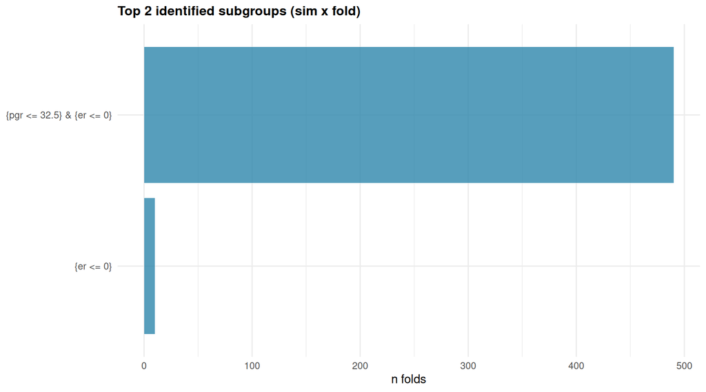

Distribution of identified subgroups across repeated 10-fold training splits.

```r
if (!is.null(cv_diag$plots) && !is.null(cv_diag$plots$identification)) {
  cv_diag$plots$identification
}
```

## 0.7 Leave-one-out (honest out-of-sample estimate)

Leave-one-out re-runs the entire selection on each hold-out of one subject and predicts the held-out subject’s subgroup membership from its covariates. It is an out-of-sample **stability check on the subgroup *definition***, not a de-biasing correction of the *effect*: it asks whether the same subgroup is recovered when no subject informs its own label. This is `forestsearch_Kfold()` at N-fold (`Kfolds = nrow(df)`), the same leave-one-out analysis carried in the multimethod document, applied to the frozen-family fit. Both the recovered definition (how often, and which) and its out-of-sample hazard ratio are reported below; see the interpretation callout for why, here, the out-of-sample HR equals Naive by construction.

Note this is the heaviest step: N-fold means one full forest search per subject (here 686 re-runs). It is tractable on the small frozen family but is the long pole; on the analysis box, not the sandbox.

The fold loop is distributed across 102 workers. `parallel_args` controls **fold-level** parallelism only – each fold’s inner `forestsearch()` refit is pinned to `plan = "sequential"`, so there is no nested oversubscription – and the fold loop draws parallel-safe L’Ecuyer streams (`.options.future = list(seed = TRUE)`). This was verified against a sequential run of the same analysis: **identical** per-subject predictions (`identical(resCV)`) and an identical out-of-sample HR, at 5.2x the speed on 11 workers (399.1 s -> 76.5 s). Parallel execution is therefore the default here.

```r
cat("Leave-one-out skipped (run_loo = FALSE).",
    "Set run_loo <- TRUE in parallel-setup to run it.\n")
```

```r
# Leave-one-out (N-fold) is the long pole -- one full forest search per subject
# (686 re-runs). If a precomputed cv_out is available (LOO_CACHE env var, else
# the default path in gh_dir) load it; otherwise run the N-fold search and cache
# it for re-renders. The fold loop runs in parallel on loo_workers workers;
# each fold's inner search is pinned sequential by forestsearch_Kfold().
#
# CACHE KEY.  The leave-one-out result is a function of the whole analysis, so
# the filename discriminates three axes:
#   * DOCUMENT (.qmd stem) -- this document and maxeff_mrconfirm both run
#     sg_focus = "maxeff" under the default selection_rule and are told apart
#     only by their candidate families (median-cut vs quantile-cut), which no
#     setting in the key would capture;
#   * canonical SG_FOCUS;
#   * resolved SELECTION_RULE -- effMaxSG and sgfocus both canonicalize to
#     "hrMaxSG" and differ ONLY here.
# A focus-only key discriminated the second axis alone, so those two documents
# shared one cache file and whichever rendered second silently reused the
# other's leave-one-out result.  Focus and rule are read from the FITTED
# object, so the key reports what the engine ran with, not what was typed.
.cache_doc   <- tryCatch(tools::file_path_sans_ext(basename(knitr::current_input())),
                         error = function(e) "analysis")
.cache_focus <- if (is.null(fs$sg_focus)) "unknownfocus" else as.character(fs$sg_focus)[1]
.cache_rule  <- {
  .r <- fs$args_call_all$selection_rule
  if (is.null(.r) || !nzchar(as.character(.r)[1])) "neighborhood" else as.character(.r)[1]
}
loo_cache <- Sys.getenv(
  "LOO_CACHE",
  unset = file.path(gh_dir, sprintf("cv_out_%s_%s_%s.rds",
                                    .cache_doc, .cache_focus, .cache_rule)))
if (file.exists(loo_cache)) {
  cv_out <- readRDS(loo_cache)
  timings$loo <- NA_real_
  cat("LOO loaded from cache:", loo_cache, "\n")
} else {
  t0 <- proc.time()
  fs_OOB <- forestsearch_Kfold(
    fs.est  = fs,
    details = FALSE,
    Kfolds  = nrow(df.analysis),   # N-fold = leave-one-out
    parallel_args = list(plan = "multisession", workers = loo_workers,
                         show_message = TRUE)
  )
  plan("sequential")
  timings$loo <- (proc.time() - t0)[["elapsed"]]
  cv_out <- forestsearch_KfoldOut(res = fs_OOB, details = FALSE, outall = TRUE)
  saveRDS(cv_out, loo_cache)
}
```

```
LOO loaded from cache: /home/larryleon/Documents/GitHub/forestsearch/quarto/applications/gbsg/_payloads_2026-09-01_complete/analysis_gbsg_survival_frozen_family/cv_out_analysis_gbsg_survival_frozen_family_maxeff_neighborhood.rds
```

```r
# Out-of-sample harm-subgroup HR, read BY IDENTITY (the harm row of the K-fold
# table, matched on its subgroup label sg0.name = "Not recommend"), never
# positionally -- the table layout depends on n_sgfound. Two structural cases:
#   (i)  stable subgroup: SG_tab_Kfold is a matrix whose harm row carries the
#        sg0.name label -> its out-of-sample HR (identical to tab_all's KfA_0);
#   (ii) ITT fallback: no subgroup survives out-of-sample (n_sgfound == 1) and
#        SG_tab_Kfold collapses to the 1-D ITT vector -> no harm row -> report
#        the fallback explicitly. Present but inactive in this frozen family.
.loo_harm_row <- function(cv_out, harm_label = "Not recommend") {
  sgk <- cv_out$SG_tab_Kfold
  if (is.matrix(sgk) && "Subgroup" %in% colnames(sgk)) {
    j <- which(sgk[, "Subgroup"] == harm_label)
    if (length(j) == 1L)
      return(list(case = "stable",
                  hr   = as.character(sgk[j, "HR (95% CI)"]),
                  n    = as.character(sgk[j, "n"])))
  }
  list(case = "itt_fallback",
       hr   = "— (no stable subgroup out-of-sample; ITT)",
       n    = NA_character_)
}
loo <- .loo_harm_row(cv_out)

# Definition stability: how many folds recovered a subgroup, and how many
# distinct definitions appeared across the 686 folds.
metr <- cv_out$sens_metrics_original
cat(sprintf(
  "LOO [%s]: out-of-sample harm HR %s (n = %s)\n  agreement: sens_H = %.2f, ppv_H = %.2f (exact-match = %.2f)\n",
  loo$case, loo$hr, loo$n, metr[["sens_H"]], metr[["ppv_H"]],
  cv_out$find_metrics[["Exact"]]))
```

```
LOO [stable]: out-of-sample harm HR 2.22 (1.17, 4.22) (n = 75 (10.9%))
  agreement: sens_H = 1.00, ppv_H = 1.00 (exact-match = 1.00)
```

```r
# Full CV tables (ITT / full-analysis / K-fold, plus agreement metrics).
tables <- cv_summary_tables(cv_out)
tables$combined_table
```

**Cross-Validation Summary**

ITT and Subgroup Estimates: Full Analysis (FA) vs K-fold (Kf)

| Analysis | Subgroup | n | n1 | m1 | m0 | RMST | Hazard ratio |
| --- | --- | --- | --- | --- | --- | --- | --- |
| Overall | ITT | 686 (100.0%) | 246 (35.9%) | 66.3 | 50.2 | 7.8 | 0.69 (0.54, 0.89) |
| FA_0 | Not recommend | 75 (10.9%) | 25 (33.3%) | 18.5 | 47.6 | -16 | 2.22 (1.17, 4.22) |
| KfA_0 | Not recommend | 75 (10.9%) | 25 (33.3%) | 18.5 | 47.6 | -16 | 2.22 (1.17, 4.22) |
| FA_1 | Recommend | 611 (89.1%) | 221 (36.2%) | 77.9 | 52.2 | 9.6 | 0.61 (0.47, 0.79) |
| KfA_1 | Recommend | 611 (89.1%) | 221 (36.2%) | 77.9 | 52.2 | 9.6 | 0.61 (0.47, 0.79) |

FA = Full Analysis (original data), Kf = K-fold CV estimate

```r
tables$metrics_table
```

**Cross-Validation Metrics**

Agreement and subgroup finding rates (%)

| Metric | Value (%) |
| --- | --- |
| Agreement |  |
| Sensitivity (H) | 100.000 |
| Sensitivity (Hc) | 100.000 |
| PPV (H) | 100.000 |
| PPV (Hc) | 100.000 |
| Finding |  |
| Any Found | 100.000 |
| Exact Match | 100.000 |
| At Least 1 | 100.000 |
| Cov1 Any | 0.000 |
| Cov2 Any | 0.000 |
| Cov1 & Cov2 | 0.000 |
| Cov1 Exact | 100.000 |
| Cov2 Exact | 100.000 |

## 0.8 Corrections in the frozen family

Subgroup hazard ratios in the FROZEN (non-regenerating) family. The FB-MR gap is the quantity of interest (see below). Guo & He reports a one-sided lower bound. Leave-one-out is NOT a de-biasing correction: it is an out-of-sample STABILITY check on the subgroup definition. It equals Naive here by construction (see the interpretation callout) – included for completeness, not as a fifth correction.

| Method | Estimate |
| --- | --- |
| Naive | 2.22 |
| Full bootstrap | 1.96 (0.81, 4.74) |
| Multiplier resampling | 1.75 (0.68, 4.52) |
| Guo & He (2021) | 1.36 (LB 0.96) |
| Leave-one-out (out-of-sample) | 2.22 (1.17, 4.22) |

```
FB debiased HR: 1.959
```

```
MR debiased HR: 1.753
```

```
FB - MR (log-HR): 0.1111
```

```
FB / MR (HR ratio): 1.1175
```

**NoteInterpretation**

If the frozen-family FB and MR debiased HRs agree up to Monte Carlo error, that corroborates the account that their divergence in the headline maxeff analysis is the family-regeneration component: FB there recomputes quantile cutpoints on each resample and so marginalizes over family regeneration (targeting the marginal $\theta^\dagger(H)$), while MR holds the fitted family fixed (targeting the conditional $\beta(\widehat{H})$). Here, with every cut fixed, there is nothing to regenerate, so the two estimands coincide and the estimators should correspond.

A small residual FB-MR difference may persist even frozen, from MR’s leading-order (infinitesimal-jackknife) approximation to the bootstrap – a distinct term from regeneration. A large residual would instead implicate that approximation and would be its own finding. This run does not, by itself, decompose those two terms; it tests whether the dominant regeneration term is removed by freezing the family.

The comparison is within-family only. The selected subgroup here differs from the headline maxeff subgroup (a coarser median-cut family), so point estimates are not comparable across the two analyses – only the FB-MR gap within each is.

Leave-one-out is **not a de-biasing correction** and should not be read as one. It is an out-of-sample **stability check on the subgroup *definition***: it asks whether the same subgroup is recovered when no subject informs its own label. Here all 686 folds recovered the *identical* definition ($\{er \le 0\} \cap \{pgr \le 32.5\}$; `sens_H = ppv_H = 1.00`, exact-match $= 1.00$).

Consequently the LOO out-of-sample HR **equals Naive by construction**, not by coincidence. The subgroup is a deterministic function of baseline covariates, and with every fold recovering the same definition, each held-out subject’s out-of-sample membership equals its in-sample membership – the harm group is the same 75 subjects and the hazard ratio is mechanically the naive one. So `LOO = Naive` while `FB, MR, GH < Naive` are **consistent**, not contradictory: they answer different questions – definition *stability* (LOO) versus effect *optimism* (the de-biasing corrections). LOO validates that the subgroup reproduces out-of-sample; it does not, and cannot here, shrink the effect.

This reproducibility is also **partly structural**: the frozen family is small, so the argmax chooses among few candidates and high fold-agreement is expected even absent deep signal. The honest claim is therefore narrow – *this* frozen definition is reproducible out-of-sample – and is **not** evidence that a finer-grained (regenerating) search would be as stable. The frozen-family LOO is included for completeness; the discriminating comparison is the headline maxeff family, where family regeneration separates FB (marginal) from MR (conditional).

## 0.9 Interval constructions for the selected subgroup

Every interval construction available for the selected subgroup $\{pgr \le 32.5\} \cap \{er \le 0\}$, side by side, on the same fit (`TASK_gbsg_frozen_intervals_2026-09-05`). The target throughout is the effect in the region the search found, **with the candidate family held fixed** — the conditional estimand this frozen-family document is built around.

Interval constructions for the selected subgroup (HR scale; SE on the log-HR scale). One-sided conventions per row: Naive and MR (IJ) use exp(log est − 1.645·SE) (MR (IJ)’s is the gate’s stored selection-adjusted bound); FB uses exp(log H2 − 1.645·SE_boot) with SE_boot = sdH2/H2 (delta method — the bootstrap object carries an SE, not the draws); MR (field)’s one-sided bound exp(β̃ − q95(Λ*)) is built on the de-biased estimate β̃, NOT on est2; Guo & He reports its own bound and is one-sided by design. The uniform row widens the field’s Λ-quantiles by κ(Σ̂) about their mean — the conservative uniformly-valid option (REPORT_mr_field_uniform_2026-09-06.md), computed here with the mass-carrying cap lifted to the full family.

| Method | Point est. | Two-sided 95% | One-sided 95% lower | SE (log-HR) |
| --- | --- | --- | --- | --- |
| Naive | 2.22 | (1.17, 4.22) | 1.30 | 0.327 |
| Full bootstrap | 1.96 | (0.81, 4.74) | 0.93 | 0.451 |
| MR (IJ) | 1.75 | (0.68, 4.52) | 0.79 | 0.484 |
| MR (field) | 1.79 | (0.76, 3.78) | 0.88 | 0.417 |
| MR (field, uniform 2s) | 1.79 | (0.46, 5.89) | 0.88 | 0.417 |
| Guo & He (2021) | 1.36 | — (one-sided by design) | 0.96 | — |

Re-selection and field diagnostics: which regime this analysis sits in. p-hat entries are the share of multiplier draws on which each candidate wins the re-selection; lambda quantities are on the log-HR scale.

| Quantity | Value |
| --- | --- |
| p-hat(H-hat) [selected: q6.1 & q8.1] | 0.678 |
| Top re-selected: q6.1 & q8.1 | 0.678 |
| 2nd: q8.1 | 0.106 |
| 3rd: q1.0 & q2.1 | 0.092 |
| Selection rate (draws with a winner) | 1.000 |
| Field lambda-bar (second-order term, log scale) | -0.0181 |
| Field lambda-SD vs se_ij (ratio) | 0.417 / 0.484 = 0.86 |
| Field lambda-SD vs naive SE (ratio) | 0.417 / 0.327 = 1.27 |
| Field draw usage (outer used / R_out; mean inner / R_in) | 1000 / 1000; 500 / 500 |
| Uniform kappa* (mcse) | 1.59 (0.054) |
| Uniform M / family size; mass covered; min C1 | 17 / 133; 0.991; 0.930 |

**NoteReading the interval constructions**

No claim is made beyond these numbers.

### 0.9.1 The complement (benefit claim) and the joint pair

Selection acts on the harm-subgroup effects; the complement $\widehat H^{c}$ is its by-product, and its naive estimate is pushed toward *benefit*. For a benefit claim (“HR in $\widehat H^{c}$ is at most $U$”) the exposed limit is the **upper** bound, so Table 3 reports the one-sided 95% upper bound as the primary column (`TASK_gbsg_frozen_complement_2026-09-06`; constructions from `TASK_mr_field_complement` and `TASK_complement_refinements`). The reported complement construction is **MR (field)**; naive, the full bootstrap and MR (IJ, two-term) are the comparators.

Table 3 — Complement (benefit claim): interval constructions for the complement of the selected subgroup (HR scale; SE on the log-HR scale). The one-sided 95% UPPER bound is the primary column: for a benefit claim the exposed limit is the upper bound (under-correction of the beneficial optimism pushes it too low and over-claims; over-correction cannot). Naive and IJ rows use exp(log est + 1.645·SE); FB uses exp(log H2 + 1.645·SE_boot) with SE_boot = sdH2/H2; MR (field) — the reported construction — is the gate’s stored upper_1s = exp(β̃ᶜ − q05(Λ*ᶜ)), built on the de-biased complement estimate β̃ᶜ, not on est2.

| Method | Point est. | Two-sided 95% | One-sided 95% upper | SE (log-HR) |
| --- | --- | --- | --- | --- |
| Naive | 0.61 | (0.47, 0.79) | 0.76 | 0.134 |
| Full bootstrap | 0.62 | (0.41, 0.94) | 0.88 | 0.210 |
| MR (IJ, two-term) | 0.62 | (0.38, 1.02) | 0.94 | 0.249 |
| MR (field) | 0.62 | (0.48, 0.82) | 0.79 | 0.139 |

Table 4 — Joint pair (Ĥ lower bound, Ĥᶜ upper bound), HR scale. (i) the two separate one-sided 95% field bounds, whose joint guarantee is below 95%; (ii) the Bonferroni pair (each tail at 2.5%); (iii) the calibrated pair from field$joint: the equal-tail level γ found on the aligned outer draws (Λ*, Λ*ᶜ) — same multipliers, same winners — such that the joint probability P*(Λ* ≤ q₁₋γ, Λ*ᶜ ≥ qγ) reaches 95%. A joint 95% guarantee is what a development claim that states BOTH bounds actually needs; with near-independent draws the calibrated pair coincides with Bonferroni, and the gain over the separate bounds is the guarantee, not the width.

| Pair | Ĥ lower | Ĥᶜ upper | Joint prob. (field draws) |
| --- | --- | --- | --- |
| Separate one-sided 95% field bounds | 0.88 | 0.79 | < 0.95 by construction |
| Bonferroni (gamma = 0.025) | 0.76 | 0.82 | 0.950 |
| Calibrated (gamma = 0.025) | 0.76 | 0.82 | 0.950 |

```
gamma = 0.025 on the 0.025-0.050 grid; corr(Lambda*, Lambda*c) = -0.104 over 1000 aligned draws.
```

**NoteReading the complement and the pair**

Read by bound location against clinically meaningful effect sizes (0.80 / 0.85 named as reading aids for a benefit, not decision rules), not as significance at HR = 1.0. Generated from the numbers above at render time:

- Complement point estimates: naive 0.61; selection-adjusted FB 0.62, MR (IJ) 0.62, field est2 0.62 — the corrections move the complement toward the null (the naive estimate carried beneficial optimism).
- One-sided 95% upper bounds, by location: the reported MR (field) 0.79; comparators FB 0.88 and MR (IJ, two-term) 0.94 (the price of its doubled SE); naive 0.76. Read against 0.80 / 0.85 as reading aids: against 0.85, MR (field) rule out a benefit weaker than 0.85; Full bootstrap and MR (IJ, two-term) do not; against 0.80, only MR (field).
- The spread across the adjusted upper bounds (0.79 to 0.94, 0.18 log-HR) is what the constructions pay for selection: the two-term IJ SE 0.249 is 1.85x the naive SE 0.134 (the doubled same-draws term), while the field’s complement lambda-SD 0.139 is 1.03x the naive SE. That the field’s complement SE coincides with the naive SE is a diagnosis, not a rule: with p-hat(H-hat) = 0.68 this analysis sits in the dominated-selection regime, where the complement’s identity barely changes across re-selection.
- The joint pair: stating both the harm lower bound and the benefit upper bound from the two separate 95% field constructions (0.88, 0.79) carries a joint guarantee below 95%; the calibrated pair (0.76, 0.82) at gamma = 0.025 coincides with the Bonferroni pair (0.76, 0.82): corr(Lambda*, Lambda*c) = -0.104, too weak a dependence to lift gamma off the Bonferroni floor on the 0.001 grid.
- Set beside the harm-side reading: in H-hat the adjusted lower bounds sit at 0.79-0.96 against the naive 1.30 — no clinically meaningful harm is established once selection is accounted for; in H-hat^c the reported field upper bound is 0.79 (FB 0.88, IJ two-term 0.94), and the joint pair is (0.76, 0.82).

| Step | Seconds | Minutes |
| --- | --- | --- |
| Fit + MR gate | 79.221 | 1.32 |
| Full bootstrap | 147.047 | 2.45 |
| MR gate (within fit) | 0.589 | 0.01 |
| MR field block (within gate) | 0.600 | 0.01 |
| MR complement field block (within gate) | 0.286 | 0.00 |
| MR uniform (kappa) sweep (within gate) | 75.833 | 1.26 |
| Guo & He bootstrap | 28.236 | 0.47 |
| 10-fold CV | 13.032 | 0.22 |
| Leave-one-out (N-fold, 102 workers) | NA | NA |

# 1 Reproducibility payload

The chunk below harvests the objects this render already computed into a single small list and writes it as an `.rds`, so the results survive the HTML. No analysis is repeated. Every element is guarded, so a section this render skipped (`run_cv_kfold`, `run_loo`) stores `NULL` rather than erroring, and the top-level names match the other GBSG payloads (`table`, `labels`, `meta`, `extras`, `est_scale`, `built_at`, `forestsearch_version`) so a reader can treat them uniformly. Schema note (2026-09-06, `TASK_gbsg_frozen_intervals`): `extras$mr` additionally carries the `field` block (the field-calibrated interval, including its `uniform` κ sub-block) and `reselection` (the re-selection frequencies `p_hat`; the per-draw `winner` vector is deliberately dropped — `sum(p_hat)` equals the selection rate and reproduces it). Schema note (2026-09-06, `TASK_gbsg_frozen_complement`): `extras$mr` additionally carries `complement` (the complement’s naive/de-biased block with the winner-only SE elements), `ij_residual`, and — inside `field` — the `complement` field block and the `joint` pair.

```
Wrote payload to: /home/larryleon/Documents/GitHub/forestsearch/quarto/applications/gbsg/_payloads/analysis_gbsg_survival_frozen_family_complement/analysis_gbsg_survival_frozen_family_complement_payload.rds
```